# code_basic

Yasmin Benitez Ortiz

2025-10-09

# **Icterus proyect**

Este proyecto forma parte de mi tema de investigación: Distribución geográfica del género Icterus, Brisson, 1760 (Icteridae) y sus implicaciones para la conservación. Que pretende identificar zonas con orígenes compuestos (nodos) para priorizar sitios de protección. El método utiliza trazos que buscan describir patrones de distribución históricos, la intersección de estos trazos se denomina nodos.

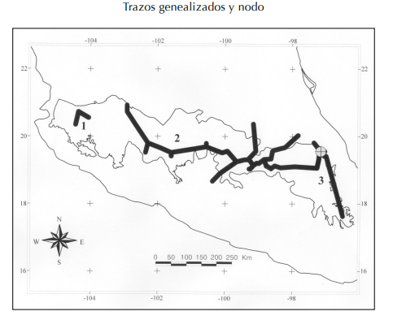

Los datos utilizados son registros geográficos de los géneros Icterus, Bursera y Sceloporus obtenidos a partir de búsquedas de presencia en el banco de datos del portal de GBIF (Global Biodiversity Information Facility, www.gbif.org/).

## Análisis clúster

Antes de localizar los trazos es importante realizar un análisis clúster, este actúa como un “filtro” que identifica patrones consistentes y repetidos. Su objetivo fundamental es identificar patrones. Esto permite identificar tendencias biogeográficas consistentes en el conjunto de datos (previo a los trazos individuales). El análisis clúster es una forma de análisis donde las observaciones se dividen en grupos significativos que comparten características comunes entre sí.

### ¿Existe un patrón general de distribución en mi conjunto de datos?

Se consultaron 19 bases de datos para el género Icterus, 93 para Bursera y 97 para Sceloporus, para especies distribuidas en México. Inicialmente cada una cuenta con 226 variables, con registros desde el año 1887 hasta 2025. El número de observaciones varía desde 42 hasta 1 943 792.

## Icterus auratus

Previo al análisis clúster se debe cuidar la calidad de los datos, realicé una limpieza de errores y bases de datos origen, asi como NA, resultando en 4 639 registros filtrados.

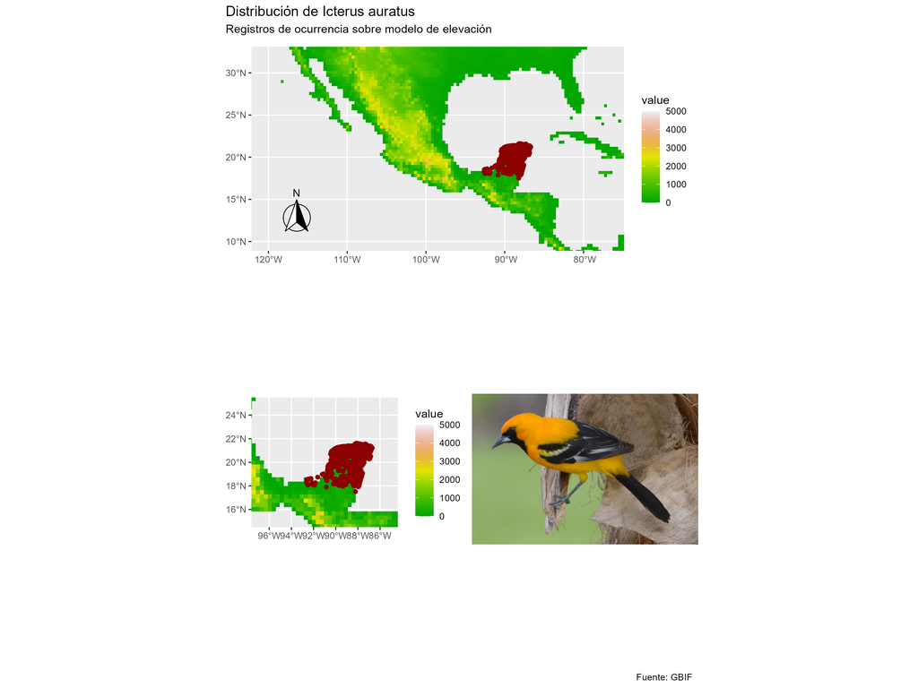

### Extracción de variables bioclimáticas

Usando capas raster y vectoriales con información bioclimática y elevación se generó una base de datos con información de cada una de las variables para cada registro georeferenciado y se obtuvo una base con 26 variables.

### Aclaramiento de coordenadas

Se encontró un marcado sobremuestreo en los registros, por lo que se realizó un aclaramiento usando la función spthin.

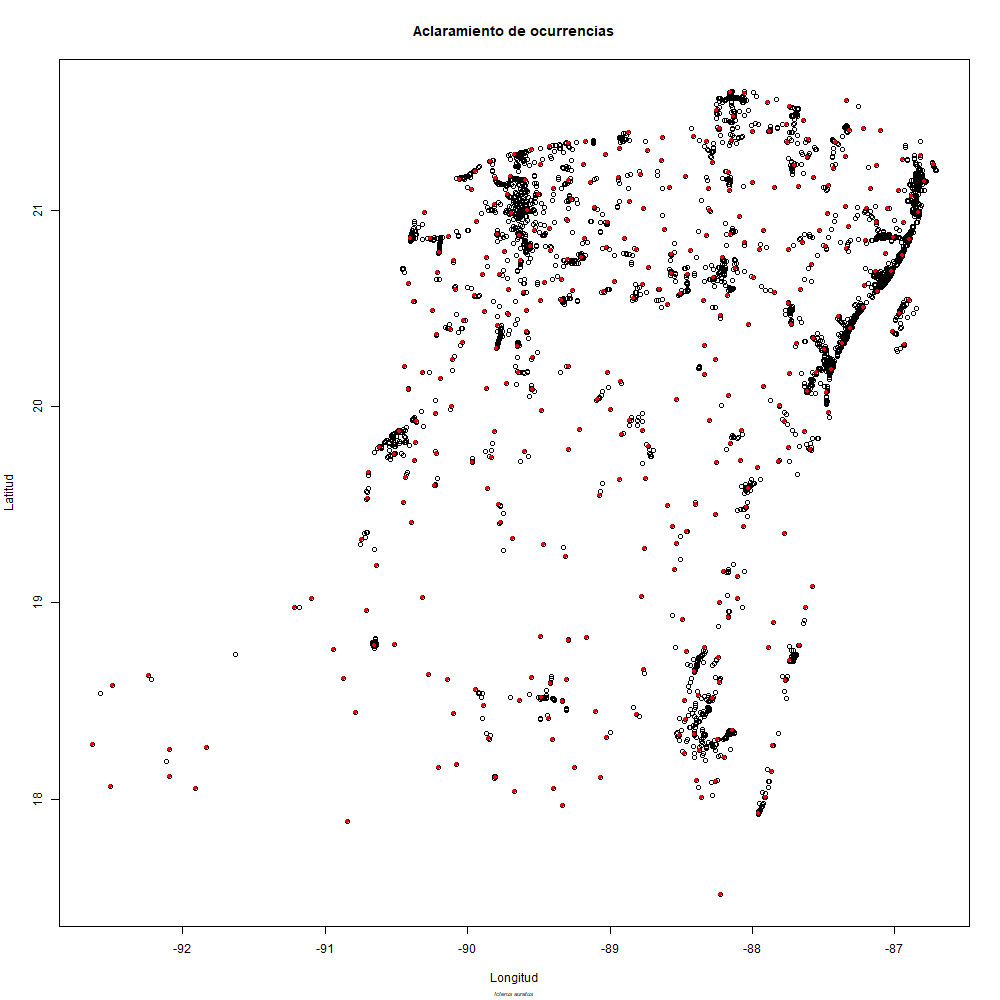

### Correlación de variables

Para encontrar que variables pueden sezgar el resultado por estar fuertemente correlacionadas se ejecutó un análisis de correlación de variables usando corrplot.

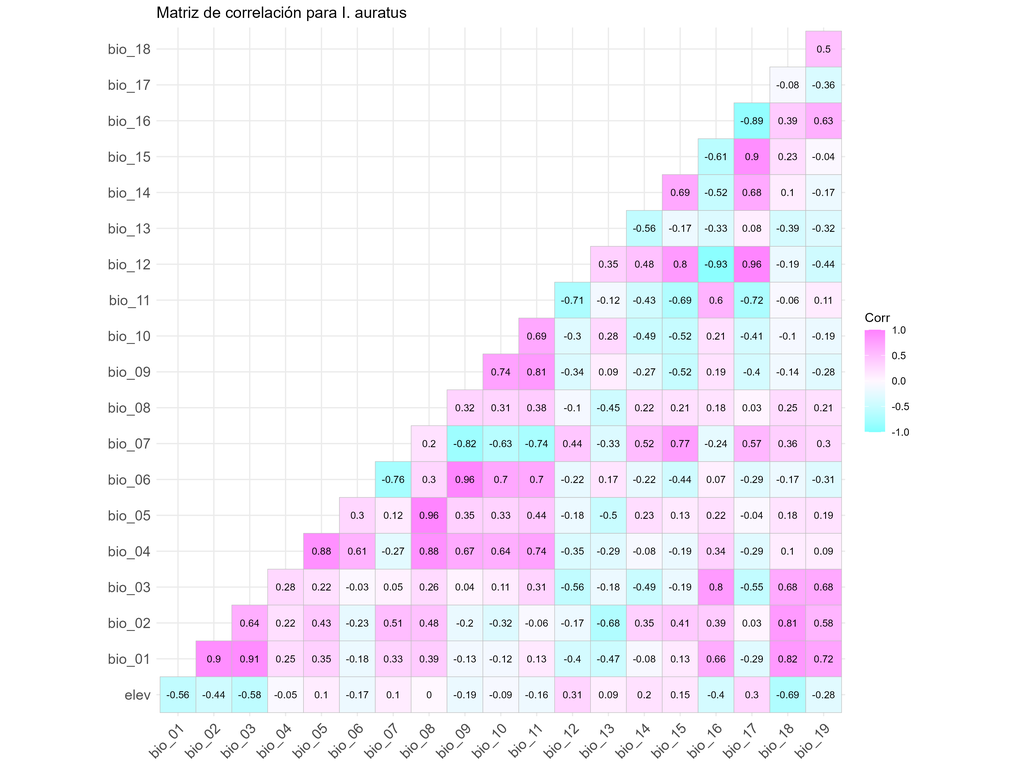

### Clúster Kmeans

Una vez preparados los datos y eliminando las variables correlacionadas del análisis se realizó un anális cluster usando el método kmeans, para encontrar el número de clúster óptimio se utilizó fviz_nbclust, que encuentra varianza dentro de los clusters en función del número de clusters (k).

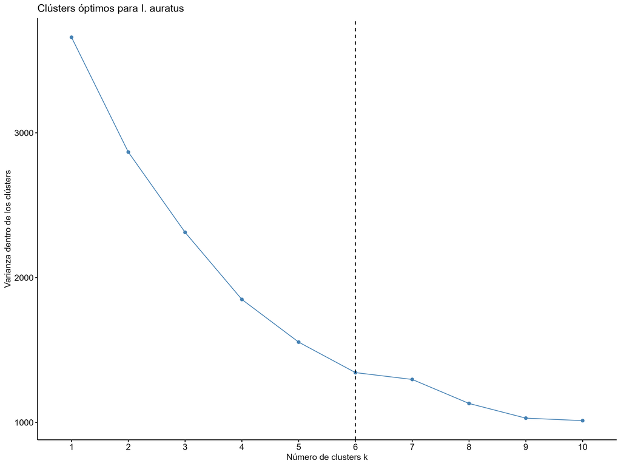

Visualización de clústers

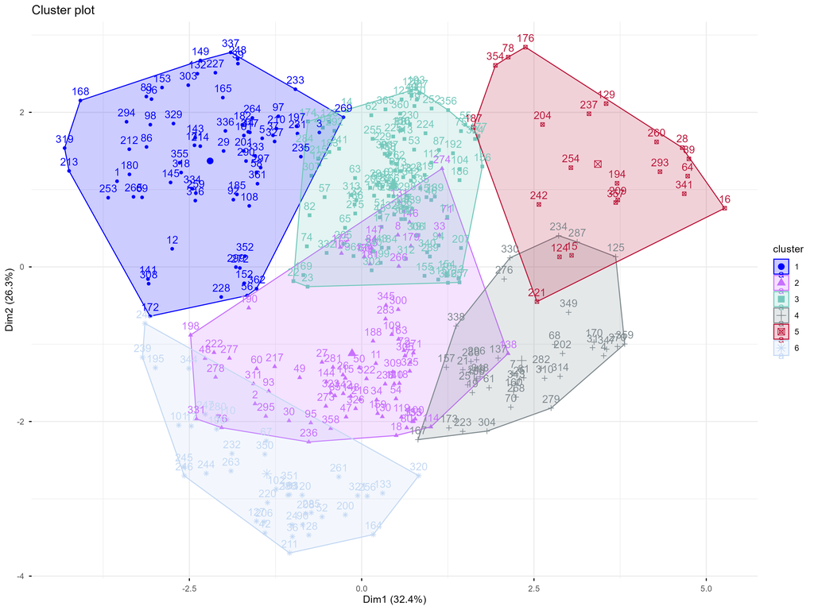